# Lab 3 - Probability - KEY

Total: 90 pts

**Load Hot Hand files:**

```r
load(url("https://stat.duke.edu/~mc301/data/hot_hand.RData"))
```

## Exercises: (50 pts)

#### Exercise 1:

```
10 pts - 5 pt for each
```

A streak length of 1 means a hit followed by a miss.

A streak length of 0 is just a miss (which must occur after a miss that ended the preceeding streak).

#### Exercise 2:

```
15 pts
* 5 pts for `kobe_streak`
* 5 pts for plot
* 5 pts for intepretation
```

The distribution of Kobe’s streaks is unimodal and right skewed. The typical length of a streak is 0 since the median of the distribution is at 0. The IQR of the distribution is 1. The longest streak of baskets is of length 4. Streak lengths of 3 and 4 are unusually high compared to the rest of the distribution.

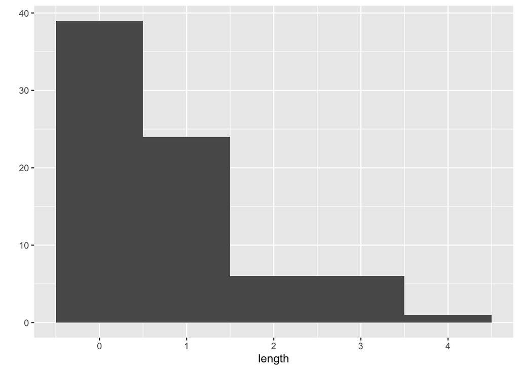

```r
kobe_streak <- calc_streak(kobe_basket$shot)
qplot(data = kobe_streak, x = length, geom = "histogram", binwidth = 1)
```

#### Exercise 3:

```
15 pts
* 5 pt for `sim_unfair_coin`
* 10 pt for `table(sim_unfair_coin)`)
```

81 tails and 19 heads (Note: Results will vary. A seed of `9102015` indicates they probably did not follow the directions.)

```r
set.seed(9102015)
coin_outcomes <- c("heads", "tails")
sim_unfair_coin <- sample(coin_outcomes, size = 100, replace = TRUE,
                          prob = c(0.2, 0.8))
table(sim_unfair_coin)
```

```
## sim_unfair_coin
## heads tails
##    19    81
```

#### Exercise 4:

```
10 pts
* 4pt for correct size
* 3pt for correct probablity
* 3pt for assigning to correct object `simbasket`
```

```r
shot_outcomes <- c("H", "M")
sim_basket <- sample(shot_outcomes, size = 133, replace = TRUE,
                     prob = c(0.45, 0.55))
```

## More practice (40pts):

#### 1

```
8pts
```

```r
sim_streak <- calc_streak(sim_basket)
```

#### 2

```
8 pts
* 4 pts for intepretation
* 4 pts for plot
```

The distribution of simulated streaks is also unimodal and right skewed. The typical length of a streak is 0 since the median of the distribution is at 0. The IQR of the distribution is 1.25. Streak lengths of 4 and above are unusually high compared to the rest of the distribution. (Note: Answers will vary.)

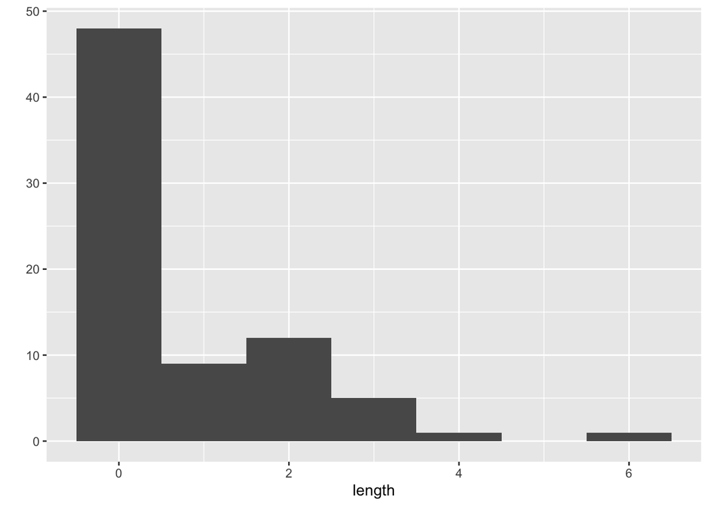

```r
qplot(data = sim_streak, x = length, geom = "histogram", binwidth = 1)
```

```r
sim_streak %>%
  summarise(median(length), IQR(length))
```

```
##   median(length) IQR(length)
## 1              0        1.25
```

#### 3:

```
8 pts - Should be similiar, but not exactly the same.
```

We would expect the distribution to be somewhat similar, i.e. unimodal and right skewed with a median around 0. But we wouldn’t get the exact same streaks, and therefore the distribution will not be exactly the same.

#### 4:

```
11 pts
* 5 pt for similar
* 6 pt for no evidence for hot hand
```

The distributions look very similar. Therefore, there doesn’t appear to be evidence for Kobe Bryant’s hot hand.

#### 5:

```
5 pts - something reasonable
```

In lecture and homework problems we have seen the concepts of independence and dependence as well as conditional probabilities. Simulations are something we’ve seen in a class activity in lecture. (Note: Answers will vary.)